# Biostatistics III in R

Code by Annika Tillander, Andreas Karlsson and Mark Clements

# Exercise 2. Comparing survival proportions and mortality rates by stage for cause-specific and all-cause survival

The purpose of this exercise is to study survival of the patients using two alternative measures — survival proportions and mortality rates. A second purpose is to study the difference between cause-specific and all-cause survival.

Load dependencies

```r
library(biostat3) # loads the survival and muhaz packages
library(dplyr)    # for data manipulation
```

We start by listing the first few observations to get an idea about the data. We then define two 1/0 variables for the events that we are interested in.

```r
## Examine the data
head(melanoma)
```

```
##      sex age     stage mmdx yydx surv_mm surv_yy       status
## 1 Female  81 Localised    2 1981    26.5     2.5  Dead: other
## 2 Female  75 Localised    9 1975    55.5     4.5  Dead: other
## 3 Female  78 Localised    2 1978   177.5    14.5  Dead: other
## 4 Female  75   Unknown    8 1975    29.5     2.5 Dead: cancer
## 5 Female  81   Unknown    7 1981    57.5     4.5  Dead: other
## 6 Female  75 Localised    9 1975    19.5     1.5 Dead: cancer
##            subsite        year8594         dx       exit agegrp id
## 1    Head and Neck Diagnosed 75-84 1981-02-02 1983-04-20    75+  1
## 2    Head and Neck Diagnosed 75-84 1975-09-21 1980-05-07    75+  2
## 3            Limbs Diagnosed 75-84 1978-02-21 1992-12-07    75+  3
## 4 Multiple and NOS Diagnosed 75-84 1975-08-25 1978-02-08    75+  4
## 5    Head and Neck Diagnosed 75-84 1981-07-09 1986-04-25    75+  5
## 6            Trunk Diagnosed 75-84 1975-09-03 1977-04-19    75+  6
##        ydx    yexit
## 1 1981.088 1983.298
## 2 1975.720 1980.348
## 3 1978.140 1992.934
## 4 1975.646 1978.104
## 5 1981.517 1986.312
## 6 1975.671 1977.296
```

```r
## Create 0/1 outcome variables
melanoma <-
    transform(melanoma,
              death_cancer = ifelse( status == "Dead: cancer", 1, 0),
              death_all = ifelse( status == "Dead: cancer" |
                                  status == "Dead: other", 1, 0))
```

## (a) Plot estimates of the survivor function and hazard function by stage.

We now tabulate the distribution of the melanoma patients by cancer stage at diagnosis.

```r
## Tabulate by stage
Freq <- xtabs(~stage, data=melanoma)
cbind(Freq, Prop=prop.table(Freq))
```

[output not shown]

We then plot the survival by stage. Does it appear that stage is associated with patient survival?

```r
par(mfrow=c(1, 2))
mfit <- survfit(Surv(surv_mm, death_cancer) ~ stage, data = melanoma)

plot(mfit, col=1:4,
     xlab = "Follow-up Time",
     ylab = "Survival")
## legend("topright", levels(melanoma$stage), col=1:4, lty = 1)

hazards <- muhaz2(Surv(surv_mm, death_cancer)~stage, melanoma)
plot(hazards,
     col=1:4, lty=1, xlim=c(0,250), ylim=c(0,0.08),
     legend=list(bty="n"))
```

[output not shown]

## (b) Estimate the mortality rates for each stage using, for example, the `survRate` command.

```r
survRate(Surv(surv_mm/12, death_cancer) ~ stage, data=melanoma)
```

```
##                     stage    tstop event       rate      lower      upper
## stage=Unknown     Unknown 10267.12   274 0.02668712 0.02362045 0.03004141
## stage=Localised Localised 38626.58  1013 0.02622546 0.02463514 0.02789150
## stage=Regional   Regional  1500.25   218 0.14530912 0.12665886 0.16593238
## stage=Distant     Distant   875.75   408 0.46588638 0.42177124 0.51336147
```

```r
melanoma %>%
    select(death_cancer, surv_mm, stage) %>%
    group_by(stage) %>%
    summarise(D = sum(death_cancer), M = sum(surv_mm/12), Rate = D/M,
              CI_low = stats::poisson.test(D,M)$conf.int[1],
              CI_high = stats::poisson.test(D,M)$conf.int[2])
```

```
## # A tibble: 4 x 6
##       stage     D        M       Rate     CI_low    CI_high
##      <fctr> <dbl>    <dbl>      <dbl>      <dbl>      <dbl>
## 1   Unknown   274 10267.12 0.02668712 0.02362045 0.03004141
## 2 Localised  1013 38626.58 0.02622546 0.02463514 0.02789150
## 3  Regional   218  1500.25 0.14530912 0.12665886 0.16593238
## 4   Distant   408   875.75 0.46588638 0.42177124 0.51336147
```

## (c) If you haven’t already done so, estimate the mortality rates for each stage per 1000 person-years of follow-up.

```r
survRate(Surv(surv_mm/12/1000, death_cancer) ~ stage, data=melanoma)
```

```
##                     stage    tstop event      rate     lower     upper
## stage=Unknown     Unknown 10.26713   274  26.68712  23.62045  30.04141
## stage=Localised Localised 38.62658  1013  26.22546  24.63514  27.89150
## stage=Regional   Regional  1.50025   218 145.30912 126.65886 165.93238
## stage=Distant     Distant  0.87575   408 465.88638 421.77124 513.36147
```

## (d)

Study whether survival is different for males and females (both by plotting the survivor function and by tabulating mortality rates).

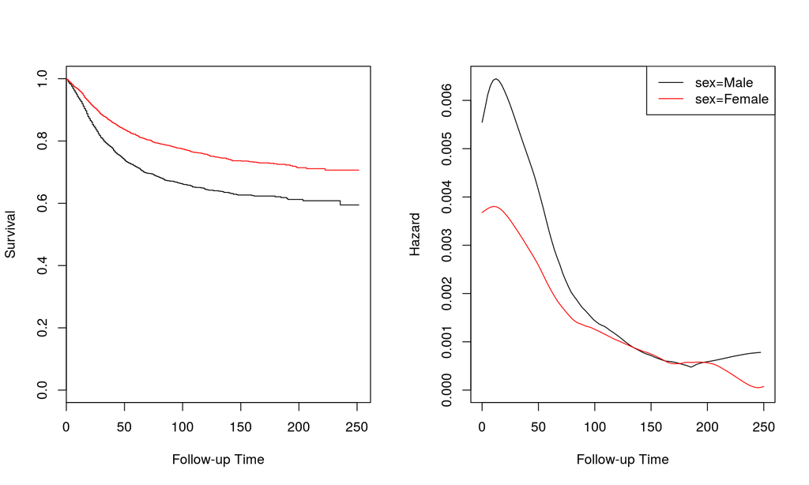

```r
par(mfrow=c(1, 2))
sfit <- survfit(Surv(surv_mm, death_cancer) ~ sex, data = melanoma)

plot(sfit, col=1:2,
     xlab = "Follow-up Time",
     ylab = "Survival")

plot(muhaz2(Surv(surv_mm,death_cancer)~sex, data = melanoma),
     col = 1:2, lty = 1)
```

Is there a difference in survival between males and females? If yes, is the difference present throughout the follow up?

## (e)

The plots you made above were based on cause-specific survival (i.e., only deaths due to cancer are counted as events, deaths due to other causes are censored). In the next part of this question we will estimate all-cause survival (i.e., any death is counted as an event). First, however, study the coding of vital status and tabulate vital status by age group.

How many patients die of each cause? Does the distribution of cause of death depend on age?

```r
xtabs(~status+agegrp, melanoma)
```

```
##                    agegrp
## status              0-44 45-59 60-74  75+
##   Alive             1615  1568  1178  359
##   Dead: cancer       386   522   640  365
##   Dead: other         39   147   461  487
##   Lost to follow-up    6     1     1    0
```

## (f)

To get all-cause survival, specify all deaths (both cancer and other) as events.

Now plot the survivor proportion for all-cause survival by stage. We name the graph to be able to separate them in the graph window. Is the survivor proportion different compared to the cause-specific survival you estimated above? Why?

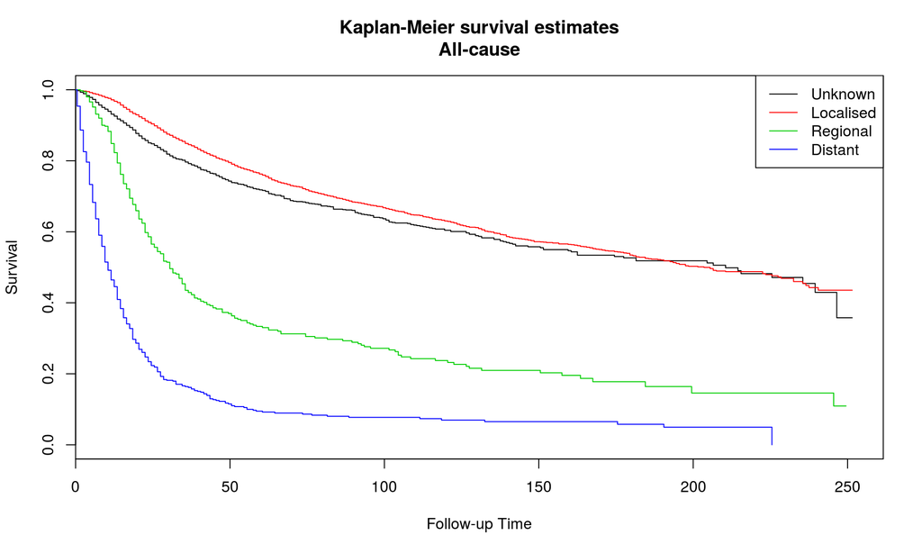

```r
par(mfrow=c(1, 1))
afit <- survfit(Surv(surv_mm, death_all) ~ stage, data = melanoma)
plot(afit, col=1:4,
     xlab = "Follow-up Time",
     ylab = "Survival",
     main = "Kaplan-Meier survival estimates\nAll-cause")
legend("topright", levels(melanoma$stage), col=1:4, lty = 1)
```

## (g)

It is more common to die from a cause other than cancer in older ages. How does this impact the survivor proportion for different stages? Compare cause-specific and all-cause survival by plotting the survivor proportion by stage for the oldest age group (75+ years) for both cause-specific and all-cause survival.

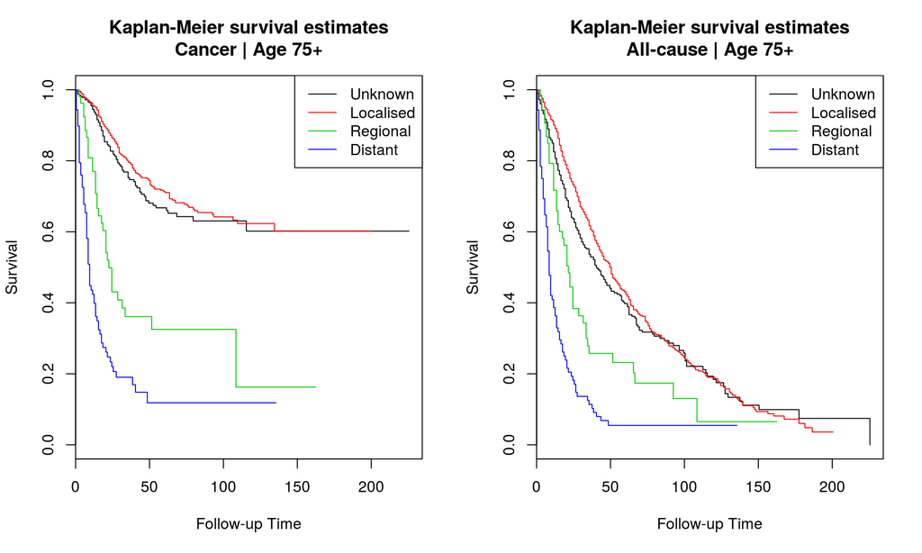

```r
par(mfrow=c(1, 2))
mfit75 <- survfit(Surv(surv_mm, death_cancer) ~ stage, data = subset(melanoma,agegrp=="75+"))
plot(mfit75, col=1:4,
     xlab = "Follow-up Time",
     ylab = "Survival",
     main = "Kaplan-Meier survival estimates\nCancer | Age 75+")
legend("topright", levels(melanoma$stage), col=1:4, lty = 1)

afit75 <- survfit(Surv(surv_mm, death_all) ~ stage, data = subset(melanoma,agegrp=="75+"))
plot(afit75, col=1:4,
     xlab = "Follow-up Time",
     ylab = "Survival",
     main = "Kaplan-Meier survival estimates\nAll-cause | Age 75+")
legend("topright", levels(melanoma$stage), col=1:4, lty = 1)
```

## (h)

Now estimate both cancer-specific and all-cause survival for each age group.

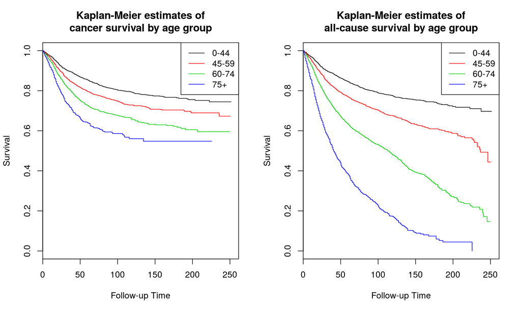

```r
par(mfrow=c(1, 2))
mfitage <- survfit(Surv(surv_mm, death_cancer) ~ agegrp, data = melanoma)
plot(mfitage, col=1:4,
     xlab = "Follow-up Time",
     ylab = "Survival",
     main = "Kaplan-Meier estimates of\ncancer survival by age group")
legend("topright", levels(melanoma$agegrp), col=1:4, lty = 1)

afitage <- survfit(Surv(surv_mm, death_all) ~ agegrp, data = melanoma)
plot(afitage, col=1:4,
     xlab = "Follow-up Time",
     ylab = "Survival",
     main = "Kaplan-Meier estimates of\nall-cause survival by age group")
legend("topright", levels(melanoma$agegrp), col=1:4, lty = 1)
```